# What’s new with Explainable AI in Julia?

An invitation to the Julia-XAI ecosystem

Adrian Hill

hill@tu-berlin.de

Technische Universität Berlin

2024-07-11

# Introduction

## Invitation to the Julia-XAI ecosystem

- **JuliaCon 2022:** ExplainableAI.jl
- **JuliaCon 2024:** Julia-XAI organization

**What kind of explanations?**

Post-hoc, local input-space explanations of black-box models:

> “Which part of the input is responsible for the model’s output?”

**Related work:** [Taija ecosystem](https://github.com/JuliaTrustworthyAI) by Patrick Altmeyer et al.

## Motivating example

[figure not shown]

```julia
using Flux, Metalhead
model = VGG(19; pretrain=true).layers
testmode!(model)

prediction = model(input)
class = argmax(prediction) # class 484: castle
```

```
CartesianIndex(484, 1)
```

Pretrained model predicts class “castle”. **But why?**

## What’s new: methods

- ExplainableAI.jl – applicable on *any* differentiable classifier
  - `Gradient`
  - `InputTimesGradient`
  - `SmoothGrad` Smilkov et al. (2017)
  - `IntegratedGradients` Sundararajan, Taly, and Yan (2017)
  - 🆕 `GradCAM` Selvaraju et al. (2017)
- 🆕 RelevancePropagation.jl – applicable on Flux.jl classifiers
  - `LRP` Bach et al. (2015)
    - 🆕 support for ResNets
    - 🆕 support for Transformers Ali et al. (2022), Achtibat et al. (2024)
  - 🆕 `CRP` Achtibat et al. (2023)

## Methods: input sensitivity

```julia
using ExplainableAI
using VisionHeatmaps

analyzer = Gradient(model)
expl = analyze(input, analyzer)
heatmap(expl)
```

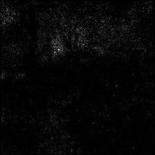

## Methods: GradCAM

```julia
using ExplainableAI
using VisionHeatmaps

analyzer = GradCAM(model[1], model[2])
expl = analyze(input, analyzer)
heatmap_overlay(expl, img)
```

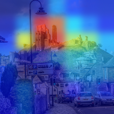

## Methods: LRP

```julia
using RelevancePropagation
using VisionHeatmaps

analyzer = LRP(model, EpsilonPlusFlat())
explanation = analyze(input, analyzer)
heatmap(explanation)
```

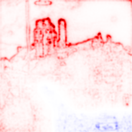

## What’s new: Julia-XAI ecosystem

[figure not shown]

## What’s new: VisionHeatmaps.jl

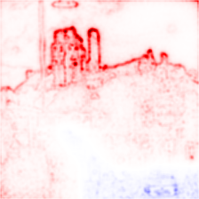

```julia
heatmap(explanation)
```

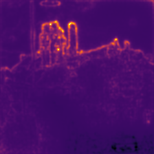

```julia
heatmap(explanation; colorscheme=:inferno, rangescale=:extrema)
```

## What’s new: TextHeatmaps.jl

Visualize explanations on **language models**

```julia
using TextHeatmaps

words = split("I loved the concert but not the opening act")
val = [0.1, 2.5, 0.0, 0.3, -0.6, -1.4, 0.0, 0.1, -0.1]
TextHeatmaps.heatmap(val, words)
```

```
WARNING: using TextHeatmaps.heatmap in module Notebook conflicts with an existing identifier.
```

Ilovedtheconcertbutnottheopeningact

```julia
TextHeatmaps.heatmap(val, words; rangescale=:extrema)
```

Ilovedtheconcertbutnottheopeningact

```julia
using ColorSchemes
TextHeatmaps.heatmap(val, words; colorscheme=:inferno)
```

Ilovedtheconcertbutnottheopeningact

## What’s new: XAIBase.jl

**Interface definition:**

1. method has to be a subtype of `AbstractXAIMethod`
2. method has to implement `analyze` function
3. method has to return `Explanation`

**Benefits**

- automatically compute heatmaps using [VisionHeatmaps.jl](https://julia-xai.github.io/XAIDocs/VisionHeatmaps/stable/) and [TextHeatmaps.jl](https://julia-xai.github.io/XAIDocs/TextHeatmaps/stable/)
- composable with e.g. [input augmentations](https://julia-xai.github.io/XAIDocs/ExplainableAI/stable/api/#Input-augmentations) from ExplainableAI.jl
- dependency free
- perfect for package extensions!

## Acknowledgements

> Adrian Hill acknowledges support by the Federal Ministry of Education and Research (BMBF) for the Berlin Institute for the Foundations of Learning and Data (BIFOLD) (01IS18037A).

[figure not shown]

## References

Achtibat, Reduan, Maximilian Dreyer, Ilona Eisenbraun, Sebastian Bosse, Thomas Wiegand, Wojciech Samek, and Sebastian Lapuschkin. 2023. “From Attribution Maps to Human-Understandable Explanations Through Concept Relevance Propagation.” *Nature Machine Intelligence* 5 (9): 1006–19. https://doi.org/10.1038/s42256-023-00711-8.

Achtibat, Reduan, Sayed Mohammad Vakilzadeh Hatefi, Maximilian Dreyer, Aakriti Jain, Thomas Wiegand, Sebastian Lapuschkin, and Wojciech Samek. 2024. “Attnlrp: Attention-Aware Layer-Wise Relevance Propagation for Transformers.” *arXiv Preprint arXiv:2402.05602*.

Ali, Ameen, Thomas Schnake, Oliver Eberle, Grégoire Montavon, Klaus-Robert Müller, and Lior Wolf. 2022. “XAI for Transformers: Better Explanations Through Conservative Propagation.” In *International Conference on Machine Learning*, 435–51. PMLR.

Bach, Sebastian, Alexander Binder, Grégoire Montavon, Frederick Klauschen, Klaus-Robert Müller, and Wojciech Samek. 2015. “On Pixel-Wise Explanations for Non-Linear Classifier Decisions by Layer-Wise Relevance Propagation.” *PloS One* 10 (7): e0130140.

Selvaraju, Ramprasaath R, Michael Cogswell, Abhishek Das, Ramakrishna Vedantam, Devi Parikh, and Dhruv Batra. 2017. “Grad-Cam: Visual Explanations from Deep Networks via Gradient-Based Localization.” In *Proceedings of the IEEE International Conference on Computer Vision*, 618–26.

Smilkov, Daniel, Nikhil Thorat, Been Kim, Fernanda Viégas, and Martin Wattenberg. 2017. “Smoothgrad: Removing Noise by Adding Noise.” *arXiv Preprint arXiv:1706.03825*.

Sundararajan, Mukund, Ankur Taly, and Qiqi Yan. 2017. “Axiomatic Attribution for Deep Networks.” In *International Conference on Machine Learning*, 3319–28. PMLR.

github.com/Julia-XAI